```python
# Data Manipulation
import numpy as np
import pandas as pd
import math
# Visualization
import matplotlib.pyplot as plt
import missingno
import seaborn as sns
from pandas.plotting import scatter_matrix
```

# A. Purpose and Content

# B. EDA, clean, handle to get a data full of useful meaning

## 1. courses

```python
# read data
courses = pd.read_csv(r"C:\Users\Thanh\Downloads\anonymisedData\courses.csv")

# Shape of data
nRow, nCol = courses.shape
print(f'There are {nRow} rows and {nCol} columns in courses table')

# Infomation
num_modules = courses.code_module.nunique()
num_presentations = courses.code_presentation.count()
print ("There are {0} modules are being offered in {1} presentations\n"
       .format(num_modules, num_presentations))

courses.info()
print("\nNumber of missing values in the data:")
print(courses.isnull().sum())

courses.head()
```

```
There are 22 rows and 3 columns in courses table
There are 7 modules are being offered in 22 presentations

<class 'pandas.core.frame.DataFrame'>
RangeIndex: 22 entries, 0 to 21
Data columns (total 3 columns):
 #   Column                      Non-Null Count  Dtype
---  ------                      --------------  -----
 0   code_module                 22 non-null     object
 1   code_presentation           22 non-null     object
 2   module_presentation_length  22 non-null     int64
dtypes: int64(1), object(2)
memory usage: 656.0+ bytes

Number of missing values in the data:
code_module                   0
code_presentation             0
module_presentation_length    0
dtype: int64
```

|  | code_module | code_presentation | module_presentation_length |
| --- | --- | --- | --- |
| 0 | AAA | 2013J | 268 |
| 1 | AAA | 2014J | 269 |
| 2 | BBB | 2013J | 268 |
| 3 | BBB | 2014J | 262 |
| 4 | BBB | 2013B | 240 |

```python
# Let’s plot the distribution of each feature
def plot_distribution(dataset, cols=5, width=20, height=15, hspace=0.2, wspace=0.5):
    plt.style.use('seaborn-whitegrid')
    fig = plt.figure(figsize=(width,height))
    fig.subplots_adjust(left=None, bottom=None, right=None, top=None, wspace=wspace, hspace=hspace)
    rows = math.ceil(float(dataset.shape[1]) / cols)
    for i, column in enumerate(dataset.columns):
        ax = fig.add_subplot(rows, cols, i + 1)
        ax.set_title(column)
        if dataset.dtypes[column] == np.object:
            g = sns.countplot(y=column, data=dataset)
            substrings = [s.get_text()[:18] for s in g.get_yticklabels()]
            g.set(yticklabels=substrings)
            plt.xticks(rotation=25)
        else:
            g = sns.distplot(dataset[column])
            plt.xticks(rotation=25)
```

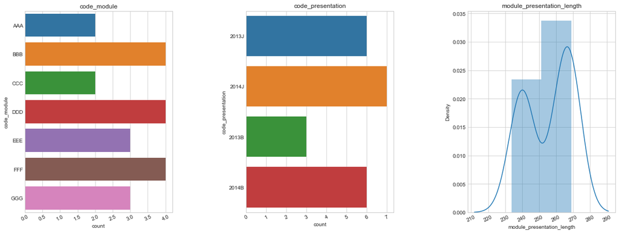

```python
# distribution of each feature
plot_distribution(courses, cols=3, width=20, height=7, hspace=0.45, wspace=0.5)
```

- Module "BBB","DDD" and "FFF" is the most open with 4 courses
- Module "AAA" and "CCC"open at least with 2 courses

```python
courses.describe()
```

|  | module_presentation_length |
| --- | --- |
| count | 22.000000 |
| mean | 255.545455 |
| std | 13.654677 |
| min | 234.000000 |
| 25% | 241.000000 |
| 50% | 261.500000 |
| 75% | 268.000000 |
| max | 269.000000 |

- A course lasts about 255 days on average ~ about 8.5 months.

```python
courses.groupby(['code_presentation']).mean()
```

| code_presentation | module_presentation_length |
| --- | --- |
| 2013B | 240.000000 |
| 2013J | 265.666667 |
| 2014B | 239.833333 |
| 2014J | 267.000000 |

- Courses held in February "B" have less study time than courses held in October "J"

## 2. studentInfo

```python
studentInfo = pd.read_csv(r"C:\Users\Thanh\Downloads\anonymisedData\studentInfo.csv")

# Shape of data
nRow, nCol = studentInfo.shape
print(f'There are {nRow} rows and {nCol} columns in studentInfo table')

# Infomation
num_students = studentInfo.id_student.nunique()
num_presentations = courses.code_presentation.count()
print ("There are {0} students \n"
       .format(num_students))

studentInfo.info()
print("\nNumber of missing values in the data:")
print(studentInfo.isnull().sum())

studentInfo.head()
```

```
There are 32593 rows and 12 columns in studentInfo table
There are 28785 students

<class 'pandas.core.frame.DataFrame'>
RangeIndex: 32593 entries, 0 to 32592
Data columns (total 12 columns):
 #   Column                Non-Null Count  Dtype
---  ------                --------------  -----
 0   code_module           32593 non-null  object
 1   code_presentation     32593 non-null  object
 2   id_student            32593 non-null  int64
 3   gender                32593 non-null  object
 4   region                32593 non-null  object
 5   highest_education     32593 non-null  object
 6   imd_band              31482 non-null  object
 7   age_band              32593 non-null  object
 8   num_of_prev_attempts  32593 non-null  int64
 9   studied_credits       32593 non-null  int64
 10  disability            32593 non-null  object
 11  final_result          32593 non-null  object
dtypes: int64(3), object(9)
memory usage: 3.0+ MB

Number of missing values in the data:
code_module                0
code_presentation          0
id_student                 0
gender                     0
region                     0
highest_education          0
imd_band                1111
age_band                   0
num_of_prev_attempts       0
studied_credits            0
disability                 0
final_result               0
dtype: int64
```

|  | code_module | code_presentation | id_student | gender | region | highest_education | imd_band | age_band | num_of_prev_attempts | studied_credits | disability | final_result |
| --- | --- | --- | --- | --- | --- | --- | --- | --- | --- | --- | --- | --- |
| 0 | AAA | 2013J | 11391 | M | East Anglian Region | HE Qualification | 90-100% | 55<= | 0 | 240 | N | Pass |
| 1 | AAA | 2013J | 28400 | F | Scotland | HE Qualification | 20-30% | 35-55 | 0 | 60 | N | Pass |
| 2 | AAA | 2013J | 30268 | F | North Western Region | A Level or Equivalent | 30-40% | 35-55 | 0 | 60 | Y | Withdrawn |
| 3 | AAA | 2013J | 31604 | F | South East Region | A Level or Equivalent | 50-60% | 35-55 | 0 | 60 | N | Pass |
| 4 | AAA | 2013J | 32885 | F | West Midlands Region | Lower Than A Level | 50-60% | 0-35 | 0 | 60 | N | Pass |

- There are 28785 students but there are 32593 records, that means there are students register in 2 or more courses.

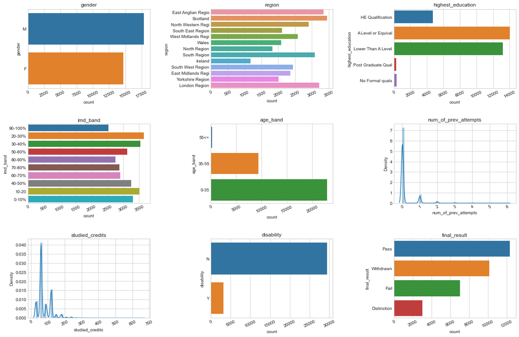

```python
plot_distribution(studentInfo.drop(columns=["id_student","code_module","code_presentation"]), cols=3, width=20, height=13, hspace=0.45, wspace=0.5)
```

- Gender: the number of male students more than female students.
- Highest_education: mostly A Level or Equivalent and Lower Than A Level.
- Age_band: Students under the age of 35 are the majority.

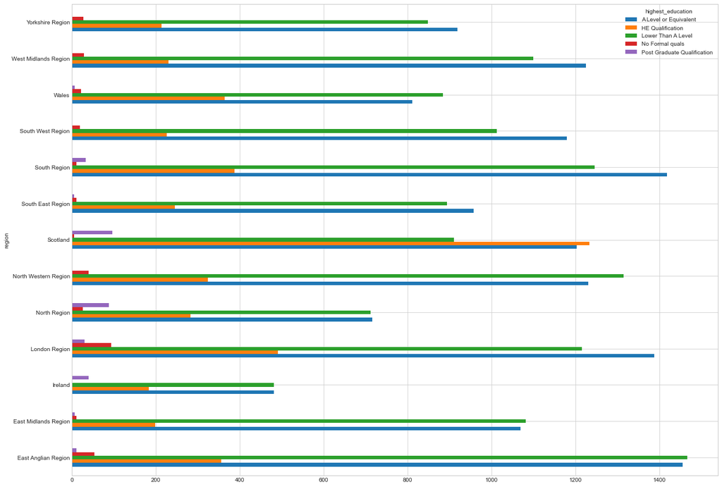

```python
ax=studentInfo.groupby('region').highest_education.value_counts()
ax.unstack().plot.barh(figsize=(20, 15))
```

### Final result with 'code_module', 'region', 'highest_education'

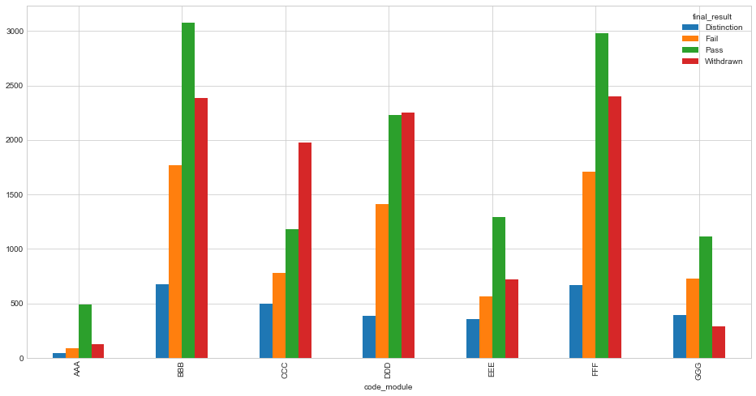

```python
# Final result with code_module
pd.crosstab(studentInfo['code_module'],studentInfo['final_result']).plot.bar(figsize=(16, 8))
```

- CCC and DDD modules have high withdrawn rate. We should pay attention to these modules.

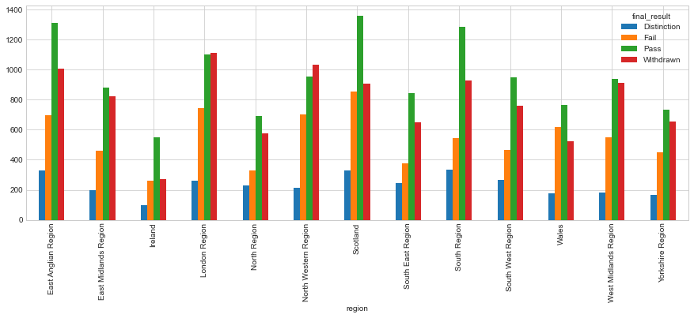

```python
# Final result with region
pd.crosstab(studentInfo['region'],studentInfo['final_result']).plot.bar(figsize=(15, 5))
```

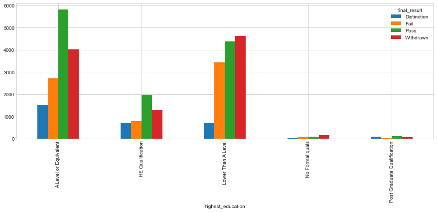

```python
# Final result with highest_education
pd.crosstab(studentInfo['highest_education'],studentInfo['final_result']).plot.bar(figsize=(15, 5))
```

- Students with 'Lower Than A Level' and 'No Formal quals' education level have high withdrawn rate.

### Distribution of final result

[output not shown]

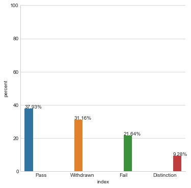

```python
df1 = studentInfo['final_result'].value_counts(normalize=True)
df1 = df1.mul(100)
df1 = df1.rename('percent').reset_index()

g = sns.catplot(x='index',y='percent',hue='index',kind='bar',data=df1)
g.ax.set_ylim(0,100)

for p in g.ax.patches:
    txt = str(p.get_height().round(2)) + '%'
    txt_x = p.get_x()
    txt_y = p.get_height()
    g.ax.text(txt_x,txt_y,txt)
```

31.16% of students withdraw from the course followed by 21.64% of students failing.

Therefore, out of the total students registering for the course, only 50% of students registered to pass the exam which signifies a problem of lower successful completion of courses by the students in the virtual learning

## 3. assessments

```python
assessments = pd.read_csv(r"C:\Users\Thanh\Downloads\anonymisedData\assessments.csv")

# Shape of data
nRow, nCol = assessments.shape
print(f'There are {nRow} rows and {nCol} columns in assessments table\n')

# Infomation
num_assessment_type = assessments.assessment_type.nunique()
num_id_assessment = assessments.id_assessment.nunique()
print ("There are {0} assessment type and {1} assessments\n"
       .format(num_assessment_type, num_id_assessment))

assessments.info()
print("\nNumber of missing values in the data:")
print(assessments.isnull().sum())

assessments.head()
```

```
There are 206 rows and 6 columns in assessments table

There are 3 assessment type and 206 assessments

<class 'pandas.core.frame.DataFrame'>
RangeIndex: 206 entries, 0 to 205
Data columns (total 6 columns):
 #   Column             Non-Null Count  Dtype
---  ------             --------------  -----
 0   code_module        206 non-null    object
 1   code_presentation  206 non-null    object
 2   id_assessment      206 non-null    int64
 3   assessment_type    206 non-null    object
 4   date               195 non-null    float64
 5   weight             206 non-null    float64
dtypes: float64(2), int64(1), object(3)
memory usage: 9.8+ KB

Number of missing values in the data:
code_module           0
code_presentation     0
id_assessment         0
assessment_type       0
date                 11
weight                0
dtype: int64
```

|  | code_module | code_presentation | id_assessment | assessment_type | date | weight |
| --- | --- | --- | --- | --- | --- | --- |
| 0 | AAA | 2013J | 1752 | TMA | 19.0 | 10.0 |
| 1 | AAA | 2013J | 1753 | TMA | 54.0 | 20.0 |
| 2 | AAA | 2013J | 1754 | TMA | 117.0 | 20.0 |
| 3 | AAA | 2013J | 1755 | TMA | 166.0 | 20.0 |
| 4 | AAA | 2013J | 1756 | TMA | 215.0 | 30.0 |

- In feature "date", there are 11 missing values at assessment_type "Exam".
- Solution: Filling them with the mean number of days of Exam assessment type.

```python
# fill missing value with mean
assessments["date"]=assessments["date"].fillna(assessments.groupby("assessment_type")["date"].transform("mean"))
assessments.isnull().sum()
```

```
code_module          0
code_presentation    0
id_assessment        0
assessment_type      0
date                 0
weight               0
dtype: int64
```

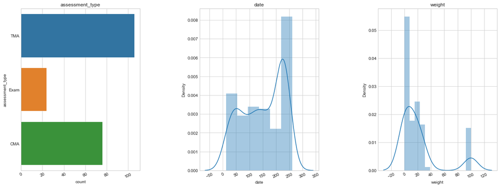

```python
plot_distribution(assessments.drop(columns=["id_assessment","code_module","code_presentation"]), cols=3, width=20, height=7, hspace=0.45, wspace=0.5)
```

- TMA type has the most number

##### Consistency of Weights of Assesments

According to the explanation of the Evaluation table, Exams are treated separately and have the weight 100%; the sum of all other assessments is 100%. Therefore, the total weight for each module_presentation should be 200.

```python
# Check consistency of Weights of Assesments
assessments.groupby(['code_module','code_presentation']).agg(total_weight = ('weight',sum))
```

| code_module | code_presentation | total_weight |
| --- | --- | --- |
| AAA | 2013J | 200.0 |
|  | 2014J | 200.0 |
| BBB | 2013B | 200.0 |
|  | 2013J | 200.0 |
|  | 2014B | 200.0 |
|  | 2014J | 200.0 |
| CCC | 2014B | 300.0 |
|  | 2014J | 300.0 |
| DDD | 2013B | 200.0 |
|  | 2013J | 200.0 |
|  | 2014B | 200.0 |
|  | 2014J | 200.0 |
| EEE | 2013J | 200.0 |
|  | 2014B | 200.0 |
|  | 2014J | 200.0 |
| FFF | 2013B | 200.0 |
|  | 2013J | 200.0 |
|  | 2014B | 200.0 |
|  | 2014J | 200.0 |
| GGG | 2013J | 100.0 |
|  | 2014B | 100.0 |
|  | 2014J | 100.0 |

- Module CCC adds up to 300 and module GGG adds up to 100 -- these 2 will be investigated.

```python
# Look at module CCC
print(assessments[assessments["code_module"]=="CCC"])
```

```
   code_module code_presentation  id_assessment assessment_type        date  \
54         CCC             2014B          24286             CMA   18.000000
55         CCC             2014B          24287             CMA   67.000000
56         CCC             2014B          24288             CMA  137.000000
57         CCC             2014B          24289             CMA  207.000000
58         CCC             2014B          24282             TMA   32.000000
59         CCC             2014B          24283             TMA  102.000000
60         CCC             2014B          24284             TMA  151.000000
61         CCC             2014B          24285             TMA  200.000000
62         CCC             2014B          24290            Exam  234.307692
63         CCC             2014B          40087            Exam  234.307692
64         CCC             2014J          24295             CMA   18.000000
65         CCC             2014J          24296             CMA   67.000000
66         CCC             2014J          24297             CMA  144.000000
67         CCC             2014J          24298             CMA  214.000000
```

[output cut: 28 more lines]

- We can see that with each code_presentation of module CCC, there are 2 exams.
- It is very likely to be entered as 2 times or this module CCC has weight of the assessment in 300%.

```python
# Look at module GGG
print(assessments[assessments["code_module"]=="GGG"])
```

```
    code_module code_presentation  id_assessment assessment_type   date  \
176         GGG             2013J          37418             CMA  229.0
177         GGG             2013J          37419             CMA  229.0
178         GGG             2013J          37420             CMA  229.0
179         GGG             2013J          37421             CMA  229.0
180         GGG             2013J          37422             CMA  229.0
181         GGG             2013J          37423             CMA  229.0
182         GGG             2013J          37415             TMA   61.0
183         GGG             2013J          37416             TMA  124.0
184         GGG             2013J          37417             TMA  173.0
185         GGG             2013J          37424            Exam  229.0
186         GGG             2014B          37428             CMA  222.0
187         GGG             2014B          37429             CMA  222.0
188         GGG             2014B          37430             CMA  222.0
189         GGG             2014B          37431             CMA  222.0
```

[output cut: 48 more lines]

- Total weight of GGG is 100 because there is no weight assigned neither to TMA type nor to CMA type.

###### Solution of inconsistion with description of CCC and GGG modules:

```python
# Weights of exams are halved for module CCC
assessments.loc[(assessments.code_module=='CCC') &(assessments.assessment_type=='Exam'),'weight'] = assessments.loc[(assessments.code_module=='CCC') &(assessments.assessment_type=='Exam'),'weight']/2
```

```python
assessments.loc[(assessments.code_module=='GGG') & (assessments.assessment_type=='TMA'),'weight']=(100/3)
```

## 4. studentAssessment

```python
studentAssessment = pd.read_csv(r"C:\Users\Thanh\Downloads\anonymisedData\studentAssessment.csv")

# Shape of data
nRow, nCol = studentAssessment.shape
print(f'There are {nRow} rows and {nCol} columns in studentAssessment table\n')

studentAssessment.info()
print("\nNumber of missing values in the data:")
print(studentAssessment.isnull().sum())

studentAssessment.head()
```

```
There are 173912 rows and 5 columns in studentAssessment table

<class 'pandas.core.frame.DataFrame'>
RangeIndex: 173912 entries, 0 to 173911
Data columns (total 5 columns):
 #   Column          Non-Null Count   Dtype
---  ------          --------------   -----
 0   id_assessment   173912 non-null  int64
 1   id_student      173912 non-null  int64
 2   date_submitted  173912 non-null  int64
 3   is_banked       173912 non-null  int64
 4   score           173739 non-null  float64
dtypes: float64(1), int64(4)
memory usage: 6.6 MB

Number of missing values in the data:
id_assessment       0
id_student          0
date_submitted      0
is_banked           0
score             173
dtype: int64
```

|  | id_assessment | id_student | date_submitted | is_banked | score |
| --- | --- | --- | --- | --- | --- |
| 0 | 1752 | 11391 | 18 | 0 | 78.0 |
| 1 | 1752 | 28400 | 22 | 0 | 70.0 |
| 2 | 1752 | 31604 | 17 | 0 | 72.0 |
| 3 | 1752 | 32885 | 26 | 0 | 69.0 |
| 4 | 1752 | 38053 | 19 | 0 | 79.0 |

###### Problem:

- How many points does each student get in total?

###### Solution:

As we all know, each id_assessment has a different percentage of points. For example, id_assessment = 1752 has weight is 10%. So,

- total score = Sum(score * weight);

We also have total weight is 200%. Infer,

- final score = total score/200.

###### Let's join Assessment and StudentAssessment tables

```python
merged_assessments = studentAssessment.merge(assessments, on='id_assessment');
merged_assessments.sort_values(by=['id_student']).head()
merged_assessments.drop(['date_submitted', 'is_banked'], axis=1, inplace=True)
merged_assessments
```

|  | id_assessment | id_student | score | code_module | code_presentation | assessment_type | date | weight |
| --- | --- | --- | --- | --- | --- | --- | --- | --- |
| 0 | 1752 | 11391 | 78.0 | AAA | 2013J | TMA | 19.0 | 10.0 |
| 1 | 1752 | 28400 | 70.0 | AAA | 2013J | TMA | 19.0 | 10.0 |
| 2 | 1752 | 31604 | 72.0 | AAA | 2013J | TMA | 19.0 | 10.0 |
| 3 | 1752 | 32885 | 69.0 | AAA | 2013J | TMA | 19.0 | 10.0 |
| 4 | 1752 | 38053 | 79.0 | AAA | 2013J | TMA | 19.0 | 10.0 |
| ... | ... | ... | ... | ... | ... | ... | ... | ... |
| 173907 | 37443 | 527538 | 60.0 | GGG | 2014J | CMA | 229.0 | 0.0 |
| 173908 | 37443 | 534672 | 100.0 | GGG | 2014J | CMA | 229.0 | 0.0 |
| 173909 | 37443 | 546286 | 80.0 | GGG | 2014J | CMA | 229.0 | 0.0 |
| 173910 | 37443 | 546724 | 100.0 | GGG | 2014J | CMA | 229.0 | 0.0 |
| 173911 | 37443 | 558486 | 80.0 | GGG | 2014J | CMA | 229.0 | 0.0 |

173912 rows × 8 columns

###### Calculate final score of each student

```python
merged_assessments['score*weight']=(merged_assessments['score']*merged_assessments['weight']) # multiple 2 parameter weighted & scores

marks=merged_assessments.groupby(['id_student','code_module','code_presentation'],as_index=False)['score*weight','weight'].sum() # sum up

marks["mark"]  = marks['score*weight']/200
marks = marks.round(1)

marks
```

|  | id_student | code_module | code_presentation | score*weight | weight | mark |
| --- | --- | --- | --- | --- | --- | --- |
| 0 | 6516 | AAA | 2014J | 6350.0 | 100.0 | 31.8 |
| 1 | 8462 | DDD | 2013J | 3490.0 | 40.0 | 17.4 |
| 2 | 8462 | DDD | 2014J | 4300.0 | 50.0 | 21.5 |
| 3 | 11391 | AAA | 2013J | 8240.0 | 100.0 | 41.2 |
| 4 | 23629 | BBB | 2013B | 1669.0 | 25.0 | 8.3 |
| ... | ... | ... | ... | ... | ... | ... |
| 25838 | 2698257 | AAA | 2013J | 6940.0 | 100.0 | 34.7 |
| 25839 | 2698535 | CCC | 2014B | 937.0 | 39.0 | 4.7 |
| 25840 | 2698535 | EEE | 2013J | 5344.0 | 100.0 | 26.7 |
| 25841 | 2698577 | BBB | 2014J | 5580.0 | 100.0 | 27.9 |
| 25842 | 2698588 | BBB | 2014J | 9240.0 | 100.0 | 46.2 |

25843 rows × 6 columns

- The mark seems to be incorrect relative to the final_result status record. With this mark, the fail rate is higher. We have to find a new solution.

###### Try a new way to calculate final score

- Case 1: Total weight of all assessments for all modules of each student doesn't adds up to 200.

  ```
    In this case, "mark" variable is calculated with this approach by assigning a 0 for missing assessment marks.
  ```

- Case 2: The score is calculated based on the weight that the student has accumulated.

  ```
    In that case,  weighted average of the assessment marks that are included in the dataset (attempted assessments) are calculated and recorded as "adjusted_mark"
  ```

  - adjusted_mark = sum(weight * score)/sum(weight)

```python
marks['adjusted_mark'] = marks['score*weight']/marks['weight']
marks = marks.round(1)
marks
```

|  | id_student | code_module | code_presentation | score*weight | weight | mark | adjusted_mark |
| --- | --- | --- | --- | --- | --- | --- | --- |
| 0 | 6516 | AAA | 2014J | 6350.0 | 100.0 | 31.8 | 63.5 |
| 1 | 8462 | DDD | 2013J | 3490.0 | 40.0 | 17.4 | 87.2 |
| 2 | 8462 | DDD | 2014J | 4300.0 | 50.0 | 21.5 | 86.0 |
| 3 | 11391 | AAA | 2013J | 8240.0 | 100.0 | 41.2 | 82.4 |
| 4 | 23629 | BBB | 2013B | 1669.0 | 25.0 | 8.3 | 66.8 |
| ... | ... | ... | ... | ... | ... | ... | ... |
| 25838 | 2698257 | AAA | 2013J | 6940.0 | 100.0 | 34.7 | 69.4 |
| 25839 | 2698535 | CCC | 2014B | 937.0 | 39.0 | 4.7 | 24.0 |
| 25840 | 2698535 | EEE | 2013J | 5344.0 | 100.0 | 26.7 | 53.4 |
| 25841 | 2698577 | BBB | 2014J | 5580.0 | 100.0 | 27.9 | 55.8 |
| 25842 | 2698588 | BBB | 2014J | 9240.0 | 100.0 | 46.2 | 92.4 |

25843 rows × 7 columns

###### Merge 2 table marks and studentInfo

```python
joined = pd.merge(marks,studentInfo,on=['id_student','code_module','code_presentation'],how='left')
joined
```

|  | id_student | code_module | code_presentation | score*weight | weight | mark | adjusted_mark | gender | region | highest_education | imd_band | age_band | num_of_prev_attempts | studied_credits | disability | final_result |
| --- | --- | --- | --- | --- | --- | --- | --- | --- | --- | --- | --- | --- | --- | --- | --- | --- |
| 0 | 6516 | AAA | 2014J | 6350.0 | 100.0 | 31.8 | 63.5 | M | Scotland | HE Qualification | 80-90% | 55<= | 0 | 60 | N | Pass |
| 1 | 8462 | DDD | 2013J | 3490.0 | 40.0 | 17.4 | 87.2 | M | London Region | HE Qualification | 30-40% | 55<= | 0 | 90 | N | Withdrawn |
| 2 | 8462 | DDD | 2014J | 4300.0 | 50.0 | 21.5 | 86.0 | M | London Region | HE Qualification | 30-40% | 55<= | 1 | 60 | N | Withdrawn |
| 3 | 11391 | AAA | 2013J | 8240.0 | 100.0 | 41.2 | 82.4 | M | East Anglian Region | HE Qualification | 90-100% | 55<= | 0 | 240 | N | Pass |
| 4 | 23629 | BBB | 2013B | 1669.0 | 25.0 | 8.3 | 66.8 | F | East Anglian Region | Lower Than A Level | 20-30% | 0-35 | 2 | 60 | N | Fail |
| ... | ... | ... | ... | ... | ... | ... | ... | ... | ... | ... | ... | ... | ... | ... | ... | ... |
| 25838 | 2698257 | AAA | 2013J | 6940.0 | 100.0 | 34.7 | 69.4 | M | East Midlands Region | Lower Than A Level | 60-70% | 0-35 | 0 | 120 | N | Pass |
| 25839 | 2698535 | CCC | 2014B | 937.0 | 39.0 | 4.7 | 24.0 | M | Wales | Lower Than A Level | 50-60% | 0-35 | 0 | 60 | N | Withdrawn |
| 25840 | 2698535 | EEE | 2013J | 5344.0 | 100.0 | 26.7 | 53.4 | M | Wales | Lower Than A Level | 50-60% | 0-35 | 0 | 60 | N | Pass |
| 25841 | 2698577 | BBB | 2014J | 5580.0 | 100.0 | 27.9 | 55.8 | F | Wales | Lower Than A Level | 50-60% | 35-55 | 0 | 60 | N | Fail |
| 25842 | 2698588 | BBB | 2014J | 9240.0 | 100.0 | 46.2 | 92.4 | F | Yorkshire Region | HE Qualification | 30-40% | 0-35 | 0 | 120 | N | Distinction |

25843 rows × 16 columns

- There are students who get close to 70 points but still fail. We will handle inconsistencies in the data

#### Strategy For Success Measure Derivation

Main strategy will be deriving the adjusted_mark value depending on attempted_weight. High attempted_weight suggest trusting on adjusted_mark or mark whereas if it is low, relying on final_result label makes more sense.

###### For students with "Distinction"

- If they have attempted_weight of 200 (attempted all assessments), their final_result will be decided according to adjusted_mark and mark (same in this case). In this case individual assessment marks are more trustworthy compared to final_result value because they add up to expected value 200.
- If they have attempted_weight between 150 and 200;

  ```
    - If adjusted_mark> 70 --> accept as it is
    - If adjusted_mark < 70 --> grey points, leave as it is
  ```

- If they have attempted_weight lower than 150, uncertainity is high for adjusted_mark. Therefore, we will mostly trust on final_result labels.These points will be ordered according to "mark" value and retaining their order, their adjusted_mark value will be assigned between 70 and 100 according to their order. ###### For students with "Pass"
- If they have attempted_weight of 200 (attempted all assessments), their final_result will be decided according to adjusted_mark and mark (same in this case).
- If they have attempted_weight between 150 and 200,

  ```
    - If adjusted_mark > 80 --> accept adjusted_mark, assign Distinction
    - If adjusted_mark < 80 --> grey points, leave as it is
  ```

- If they have attempted_weight lower than 150, again, high uncertainty of "mark". Therefore, we will mostly trust on final_result labels.These points will be ordered according to mark value and retaining their order, their adjusted_mark value will be assigned between 40 and 70 according to their order. This approach is used again because with decreasing total_weight, we mostly rely on already given final_result value. Therefore, assigned adjusted_mark according to given "Pass" label.

###### For students with "Fail"

- If they have attempted_weight of 200 (attempted all assessments), their final_result will be decided according to adjusted_mark and mark (same in this case).
- If they have attempted_weight between 150 and 200,

  ```
    - mark > 40 --> adjusted_mark = mark and label = "Pass"
    - mark < 40 --> grey points, leave as it is
  ```

- If they have attempted_weight lower than 150. Again, uncertainity is high. Rely on final_result.Same approach will be followed as in "Pass" and "Distinction" sections. These values will be ordered according to mark value and retaining their order, their adjusted_mark value will be assigned between 0 and 40 according to their order.

```python
distinction = joined[joined.final_result=="Distinction"].index
passing = joined[joined.final_result=="Pass"].index
fail = joined[joined.final_result=="Fail"].index
withdraw = joined[joined.final_result=="Withdraw"].index


weight200 = joined[joined.weight==200].index
weight150_200 = joined[(joined.weight>=150) & (joined.weight!=200)].index
weight0_150 = joined.index.difference(weight200).difference(weight150_200)

adj_mark80_100 = joined[joined.weight>=80].index
adj_mark70_80 = joined[(joined.weight>=70) & (joined.weight<80)].index
adj_mark0_70 = joined[joined.weight<70].index

mark40_100 = joined[joined.weight>=40].index
mark0_40 = joined[joined.weight<40].index
```

```python
# Students with attempted_weight 200
joined.loc[(weight200) & (adj_mark80_100), "final_result"] = "Distinction"
joined.loc[(weight200) & (adj_mark70_80), "final_result"] = "Pass"
joined.loc[(weight200) & (adj_mark0_70), "final_result"] = "Fail"

# Students with attempted_weight between 150 and 200
joined.loc[(weight150_200) & (passing) & (adj_mark80_100), "final_result"] = "Distinction"
joined.loc[(weight150_200) & (fail) & (mark40_100), "final_result"] = "Pass"
joined.loc[(weight150_200) & (fail) & (mark40_100), "adjusted_mark"] = joined.loc[(weight150_200) & (fail) & (mark40_100), "mark"]

# Students with attempted_weight lower than 150 -- Ordering and reassigning adj_mark as explained above
joined.loc[joined.loc[(weight0_150) & (distinction)].mark.sort_values().index,"adjusted_mark"] = np.arange(70.0, 100.0, 30/len(joined.loc[(weight0_150) & (distinction)]))
joined.loc[joined.loc[(weight0_150) & (passing)].mark.sort_values().index,"adjusted_mark"] = np.arange(40.0, 70.0, 30/len(joined.loc[(weight0_150) & (passing)]))
joined.loc[joined.loc[(weight0_150) & (fail)].mark.sort_values().index,"adjusted_mark"] = np.arange(0.0, 40.0, 40/len(joined.loc[(weight0_150) & (fail)]))

df = joined
```

- There can be students who attempt some of the assignments but then withdraw the course, mark variable may have a value for these students. ###### These marks shouldn't be used in analysis so will be replaced with NaN as follows.

```python
df.loc[joined.final_result=='Withdrawn','mark']= np.nan
df
```

|  | id_student | code_module | code_presentation | score*weight | weight | mark | adjusted_mark | gender | region | highest_education | imd_band | age_band | num_of_prev_attempts | studied_credits | disability | final_result |
| --- | --- | --- | --- | --- | --- | --- | --- | --- | --- | --- | --- | --- | --- | --- | --- | --- |
| 0 | 6516 | AAA | 2014J | 6350.0 | 100.0 | 31.8 | 48.055203 | M | Scotland | HE Qualification | 80-90% | 55<= | 0 | 60 | N | Pass |
| 1 | 8462 | DDD | 2013J | 3490.0 | 40.0 | NaN | 87.200000 | M | London Region | HE Qualification | 30-40% | 55<= | 0 | 90 | N | Withdrawn |
| 2 | 8462 | DDD | 2014J | 4300.0 | 50.0 | NaN | 86.000000 | M | London Region | HE Qualification | 30-40% | 55<= | 1 | 60 | N | Withdrawn |
| 3 | 11391 | AAA | 2013J | 8240.0 | 100.0 | 41.2 | 64.006980 | M | East Anglian Region | HE Qualification | 90-100% | 55<= | 0 | 240 | N | Pass |
| 4 | 23629 | BBB | 2013B | 1669.0 | 25.0 | 8.3 | 13.836719 | F | East Anglian Region | Lower Than A Level | 20-30% | 0-35 | 2 | 60 | N | Fail |
| ... | ... | ... | ... | ... | ... | ... | ... | ... | ... | ... | ... | ... | ... | ... | ... | ... |
| 25838 | 2698257 | AAA | 2013J | 6940.0 | 100.0 | 34.7 | 52.388959 | M | East Midlands Region | Lower Than A Level | 60-70% | 0-35 | 0 | 120 | N | Pass |
| 25839 | 2698535 | CCC | 2014B | 937.0 | 39.0 | NaN | 24.000000 | M | Wales | Lower Than A Level | 50-60% | 0-35 | 0 | 60 | N | Withdrawn |
| 25840 | 2698535 | EEE | 2013J | 5344.0 | 100.0 | 26.7 | 43.023477 | M | Wales | Lower Than A Level | 50-60% | 0-35 | 0 | 60 | N | Pass |
| 25841 | 2698577 | BBB | 2014J | 5580.0 | 100.0 | 27.9 | 33.491759 | F | Wales | Lower Than A Level | 50-60% | 35-55 | 0 | 60 | N | Fail |
| 25842 | 2698588 | BBB | 2014J | 9240.0 | 100.0 | 46.2 | 95.111402 | F | Yorkshire Region | HE Qualification | 30-40% | 0-35 | 0 | 120 | N | Distinction |

25843 rows × 16 columns

## 5. studentRegistration

```python
studentRegistration = pd.read_csv(r"C:\Users\Thanh\Downloads\anonymisedData\studentRegistration.csv")

# Shape of data
nRow, nCol = studentRegistration.shape
print(f'There are {nRow} rows and {nCol} columns in studentRegistration table')

# Infomation
num_registrations = studentRegistration.id_student.count()
print ("There are {0} registrations from {1} students\n"
       .format(num_registrations, num_students))

studentRegistration.info()
print("\nNumber of missing values in the data:")
print(studentRegistration.isnull().sum())

studentRegistration.head()
```

```
There are 32593 rows and 5 columns in studentRegistration table
There are 32593 registrations from 28785 students

<class 'pandas.core.frame.DataFrame'>
RangeIndex: 32593 entries, 0 to 32592
Data columns (total 5 columns):
 #   Column               Non-Null Count  Dtype
---  ------               --------------  -----
 0   code_module          32593 non-null  object
 1   code_presentation    32593 non-null  object
 2   id_student           32593 non-null  int64
 3   date_registration    32548 non-null  float64
 4   date_unregistration  10072 non-null  float64
dtypes: float64(2), int64(1), object(2)
memory usage: 1.2+ MB

Number of missing values in the data:
code_module                0
code_presentation          0
id_student                 0
date_registration         45
date_unregistration    22521
dtype: int64
```

|  | code_module | code_presentation | id_student | date_registration | date_unregistration |
| --- | --- | --- | --- | --- | --- |
| 0 | AAA | 2013J | 11391 | -159.0 | NaN |
| 1 | AAA | 2013J | 28400 | -53.0 | NaN |
| 2 | AAA | 2013J | 30268 | -92.0 | 12.0 |
| 3 | AAA | 2013J | 31604 | -52.0 | NaN |
| 4 | AAA | 2013J | 32885 | -176.0 | NaN |

```python
studentRegistration.describe()
```

|  | id_student | date_registration | date_unregistration |
| --- | --- | --- | --- |
| count | 3.259300e+04 | 32548.000000 | 10072.000000 |
| mean | 7.066877e+05 | -69.411300 | 49.757645 |
| std | 5.491673e+05 | 49.260522 | 82.460890 |
| min | 3.733000e+03 | -322.000000 | -365.000000 |
| 25% | 5.085730e+05 | -100.000000 | -2.000000 |
| 50% | 5.903100e+05 | -57.000000 | 27.000000 |
| 75% | 6.444530e+05 | -29.000000 | 109.000000 |
| max | 2.716795e+06 | 167.000000 | 444.000000 |

```python
# transform all values into positive values
studentRegistration[["date_registration","date_unregistration"]]=studentRegistration[["date_registration","date_unregistration"]].abs()
```

### I want to know what courses do students withdraw from and at what rate?

```python
stu_withdrawn = studentInfo[studentInfo["final_result"]=="Withdrawn"]

total_stuWithdrawn=stu_withdrawn.groupby(["code_module","code_presentation"]).agg(quantity= ('id_student',"count"))

total_stu_by_presentation= studentRegistration.groupby(["code_module","code_presentation"]).agg(quantity= ('id_student',"count"))

total_stuWithdrawn["%"]=(total_stuWithdrawn["quantity"]/total_stu_by_presentation["quantity"])*100

total_stuWithdrawn
```

| code_module | code_presentation | quantity | % |
| --- | --- | --- | --- |
| AAA | 2013J | 60 | 15.665796 |
|  | 2014J | 66 | 18.082192 |
| BBB | 2013B | 505 | 28.579513 |
|  | 2013J | 644 | 28.788556 |
|  | 2014B | 490 | 30.378177 |
|  | 2014J | 749 | 32.678883 |
| CCC | 2014B | 898 | 46.384298 |
|  | 2014J | 1077 | 43.114492 |
| DDD | 2013B | 432 | 33.154259 |
|  | 2013J | 681 | 35.139319 |
|  | 2014B | 490 | 39.902280 |
|  | 2014J | 647 | 35.884637 |
| EEE | 2013J | 243 | 23.098859 |
|  | 2014B | 173 | 24.927954 |
|  | 2014J | 306 | 25.757576 |
| FFF | 2013B | 411 | 25.464684 |
|  | 2013J | 675 | 29.566360 |
|  | 2014B | 462 | 30.800000 |
|  | 2014J | 855 | 36.152220 |
| GGG | 2013J | 66 | 6.932773 |
|  | 2014B | 100 | 12.004802 |
|  | 2014J | 126 | 16.822430 |

## 6. vle

```python
vle = pd.read_csv(r"C:\Users\Thanh\Downloads\anonymisedData\vle.csv")

# Shape of data
nRow, nCol = vle.shape
print(f'There are {nRow} rows and {nCol} columns in vle table')

# Infomation
num_vles = vle.id_site.count()
print ("There are {0} VLEs\n"
       .format(num_vles))

vle.info()
print("\nNumber of missing values in the data:")
print(vle.isnull().sum())

vle.head()
```

```
There are 6364 rows and 6 columns in vle table
There are 6364 VLEs

<class 'pandas.core.frame.DataFrame'>
RangeIndex: 6364 entries, 0 to 6363
Data columns (total 6 columns):
 #   Column             Non-Null Count  Dtype
---  ------             --------------  -----
 0   id_site            6364 non-null   int64
 1   code_module        6364 non-null   object
 2   code_presentation  6364 non-null   object
 3   activity_type      6364 non-null   object
 4   week_from          1121 non-null   float64
 5   week_to            1121 non-null   float64
dtypes: float64(2), int64(1), object(3)
memory usage: 298.4+ KB

Number of missing values in the data:
id_site                 0
code_module             0
code_presentation       0
activity_type           0
week_from            5243
week_to              5243
dtype: int64
```

|  | id_site | code_module | code_presentation | activity_type | week_from | week_to |
| --- | --- | --- | --- | --- | --- | --- |
| 0 | 546943 | AAA | 2013J | resource | NaN | NaN |
| 1 | 546712 | AAA | 2013J | oucontent | NaN | NaN |
| 2 | 546998 | AAA | 2013J | resource | NaN | NaN |
| 3 | 546888 | AAA | 2013J | url | NaN | NaN |
| 4 | 547035 | AAA | 2013J | resource | NaN | NaN |

- Most of the entries of 'week_from' and 'week_to' attributes are missing but the analysis will not be focusing on the dates. So we will remove them

```python
vle= vle.iloc[:,0:4]
vle.head()
```

|  | id_site | code_module | code_presentation | activity_type |
| --- | --- | --- | --- | --- |
| 0 | 546943 | AAA | 2013J | resource |
| 1 | 546712 | AAA | 2013J | oucontent |
| 2 | 546998 | AAA | 2013J | resource |
| 3 | 546888 | AAA | 2013J | url |
| 4 | 547035 | AAA | 2013J | resource |

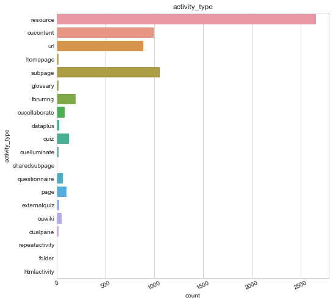

```python
plot_distribution(vle.drop(columns=["id_site","code_module","code_presentation"]), cols=2, width=20, height=8, hspace=0.45, wspace=0.5)
```

## 7.studentVle

```python
studentVle = pd.read_csv(r"C:\Users\Thanh\Downloads\anonymisedData\studentVle.csv")

# Shape of data
nRow, nCol = studentVle.shape
print(f'There are {nRow} rows and {nCol} columns in studentVle table\n')

studentVle.info()
print("\nNumber of missing values in the data:")
print(studentVle.isnull().sum())

studentVle.head()
```

```
There are 10655280 rows and 6 columns in studentVle table

<class 'pandas.core.frame.DataFrame'>
RangeIndex: 10655280 entries, 0 to 10655279
Data columns (total 6 columns):
 #   Column             Dtype
---  ------             -----
 0   code_module        object
 1   code_presentation  object
 2   id_student         int64
 3   id_site            int64
 4   date               int64
 5   sum_click          int64
dtypes: int64(4), object(2)
memory usage: 487.8+ MB

Number of missing values in the data:
code_module          0
code_presentation    0
id_student           0
id_site              0
date                 0
sum_click            0
dtype: int64
```

|  | code_module | code_presentation | id_student | id_site | date | sum_click |
| --- | --- | --- | --- | --- | --- | --- |
| 0 | AAA | 2013J | 28400 | 546652 | -10 | 4 |
| 1 | AAA | 2013J | 28400 | 546652 | -10 | 1 |
| 2 | AAA | 2013J | 28400 | 546652 | -10 | 1 |
| 3 | AAA | 2013J | 28400 | 546614 | -10 | 11 |
| 4 | AAA | 2013J | 28400 | 546714 | -10 | 1 |

###### Merge 2 table vle and studentVle

```python
merged_vle = studentVle.merge(vle, on=['id_site','code_module','code_presentation'])
merged_vle.head()
```

|  | code_module | code_presentation | id_student | id_site | date | sum_click | activity_type |
| --- | --- | --- | --- | --- | --- | --- | --- |
| 0 | AAA | 2013J | 28400 | 546652 | -10 | 4 | forumng |
| 1 | AAA | 2013J | 28400 | 546652 | -10 | 1 | forumng |
| 2 | AAA | 2013J | 28400 | 546652 | -10 | 1 | forumng |
| 3 | AAA | 2013J | 28400 | 546652 | -10 | 8 | forumng |
| 4 | AAA | 2013J | 30268 | 546652 | -10 | 3 | forumng |

```python
merged_vle = merged_vle.groupby(['id_student', 'code_module', 'code_presentation', 'activity_type'])
vle_visits = merged_vle['date'].count().reset_index()
vle_visits.head(20)
```

|  | id_student | code_module | code_presentation | activity_type | date |
| --- | --- | --- | --- | --- | --- |
| 0 | 6516 | AAA | 2014J | dataplus | 4 |
| 1 | 6516 | AAA | 2014J | forumng | 175 |
| 2 | 6516 | AAA | 2014J | homepage | 158 |
| 3 | 6516 | AAA | 2014J | oucontent | 184 |
| 4 | 6516 | AAA | 2014J | resource | 19 |
| 5 | 6516 | AAA | 2014J | subpage | 73 |
| 6 | 6516 | AAA | 2014J | url | 49 |
| 7 | 8462 | DDD | 2013J | externalquiz | 9 |
| 8 | 8462 | DDD | 2013J | forumng | 19 |
| 9 | 8462 | DDD | 2013J | homepage | 52 |
| 10 | 8462 | DDD | 2013J | oucollaborate | 7 |
| 11 | 8462 | DDD | 2013J | oucontent | 26 |
| 12 | 8462 | DDD | 2013J | ouwiki | 5 |
| 13 | 8462 | DDD | 2013J | resource | 51 |
| 14 | 8462 | DDD | 2013J | subpage | 114 |
| 15 | 8462 | DDD | 2013J | url | 17 |
| 16 | 8462 | DDD | 2014J | forumng | 2 |
| 17 | 8462 | DDD | 2014J | homepage | 1 |
| 18 | 8462 | DDD | 2014J | oucollaborate | 1 |
| 19 | 11391 | AAA | 2013J | forumng | 52 |

```python
vle_clicks = merged_vle['sum_click'].sum().reset_index()
vle_clicks.head(20)
```

|  | id_student | code_module | code_presentation | activity_type | sum_click |
| --- | --- | --- | --- | --- | --- |
| 0 | 6516 | AAA | 2014J | dataplus | 21 |
| 1 | 6516 | AAA | 2014J | forumng | 451 |
| 2 | 6516 | AAA | 2014J | homepage | 497 |
| 3 | 6516 | AAA | 2014J | oucontent | 1505 |
| 4 | 6516 | AAA | 2014J | resource | 31 |
| 5 | 6516 | AAA | 2014J | subpage | 143 |
| 6 | 6516 | AAA | 2014J | url | 143 |
| 7 | 8462 | DDD | 2013J | externalquiz | 12 |
| 8 | 8462 | DDD | 2013J | forumng | 36 |
| 9 | 8462 | DDD | 2013J | homepage | 184 |
| 10 | 8462 | DDD | 2013J | oucollaborate | 12 |
| 11 | 8462 | DDD | 2013J | oucontent | 64 |
| 12 | 8462 | DDD | 2013J | ouwiki | 18 |
| 13 | 8462 | DDD | 2013J | resource | 70 |
| 14 | 8462 | DDD | 2013J | subpage | 227 |
| 15 | 8462 | DDD | 2013J | url | 23 |
| 16 | 8462 | DDD | 2014J | forumng | 2 |
| 17 | 8462 | DDD | 2014J | homepage | 7 |
| 18 | 8462 | DDD | 2014J | oucollaborate | 1 |
| 19 | 11391 | AAA | 2013J | forumng | 193 |

```python
total_click = studentVle.groupby(["id_student","code_module","code_presentation"]).agg( total_click = ('sum_click',sum))
total_click
```

| id_student | code_module | code_presentation | total_click |
| --- | --- | --- | --- |
| 6516 | AAA | 2014J | 2791 |
| 8462 | DDD | 2013J | 646 |
|  |  | 2014J | 10 |
| 11391 | AAA | 2013J | 934 |
| 23629 | BBB | 2013B | 161 |
| ... | ... | ... | ... |
| 2698257 | AAA | 2013J | 758 |
| 2698535 | CCC | 2014B | 786 |
|  | EEE | 2013J | 3455 |
| 2698577 | BBB | 2014J | 717 |
| 2698588 | BBB | 2014J | 605 |

29228 rows × 1 columns

```python
data = studentInfo.merge(vle_clicks, on=['id_student','code_module','code_presentation'])
data = data.merge(total_click, on=['id_student','code_module','code_presentation'])
data
```

|  | code_module | code_presentation | id_student | gender | region | highest_education | imd_band | age_band | num_of_prev_attempts | studied_credits | disability | final_result | activity_type | sum_click | total_click |
| --- | --- | --- | --- | --- | --- | --- | --- | --- | --- | --- | --- | --- | --- | --- | --- |
| 0 | AAA | 2013J | 11391 | M | East Anglian Region | HE Qualification | 90-100% | 55<= | 0 | 240 | N | Pass | forumng | 193 | 934 |
| 1 | AAA | 2013J | 11391 | M | East Anglian Region | HE Qualification | 90-100% | 55<= | 0 | 240 | N | Pass | homepage | 138 | 934 |
| 2 | AAA | 2013J | 11391 | M | East Anglian Region | HE Qualification | 90-100% | 55<= | 0 | 240 | N | Pass | oucontent | 553 | 934 |
| 3 | AAA | 2013J | 11391 | M | East Anglian Region | HE Qualification | 90-100% | 55<= | 0 | 240 | N | Pass | resource | 13 | 934 |
| 4 | AAA | 2013J | 11391 | M | East Anglian Region | HE Qualification | 90-100% | 55<= | 0 | 240 | N | Pass | subpage | 32 | 934 |
| ... | ... | ... | ... | ... | ... | ... | ... | ... | ... | ... | ... | ... | ... | ... | ... |
| 240352 | GGG | 2014J | 2684003 | F | Yorkshire Region | HE Qualification | 50-60% | 35-55 | 0 | 30 | N | Distinction | homepage | 120 | 616 |
| 240353 | GGG | 2014J | 2684003 | F | Yorkshire Region | HE Qualification | 50-60% | 35-55 | 0 | 30 | N | Distinction | oucontent | 265 | 616 |
| 240354 | GGG | 2014J | 2684003 | F | Yorkshire Region | HE Qualification | 50-60% | 35-55 | 0 | 30 | N | Distinction | quiz | 60 | 616 |
| 240355 | GGG | 2014J | 2684003 | F | Yorkshire Region | HE Qualification | 50-60% | 35-55 | 0 | 30 | N | Distinction | resource | 33 | 616 |
| 240356 | GGG | 2014J | 2684003 | F | Yorkshire Region | HE Qualification | 50-60% | 35-55 | 0 | 30 | N | Distinction | subpage | 27 | 616 |

240357 rows × 15 columns

```python
avgClick_byResult = data.groupby(["final_result","activity_type"]).agg( avg_click = ('total_click', 'mean'))
avgClick_byResult.head(60)
```

| final_result | activity_type | avg_click |
| --- | --- | --- |
| Distinction | dataplus | 5449.000000 |
|  | dualpane | 4955.432353 |
|  | externalquiz | 2008.535809 |
|  | folder | 4990.955631 |
|  | forumng | 2703.015167 |
|  | glossary | 2286.667033 |
|  | homepage | 2666.758929 |
|  | htmlactivity | 5284.457031 |
|  | oucollaborate | 3337.862113 |
|  | oucontent | 2703.413653 |
|  | ouelluminate | 3972.464602 |
|  | ouwiki | 3934.898438 |
|  | page | 4137.786656 |
|  | questionnaire | 4739.830287 |
|  | quiz | 2759.391170 |
|  | resource | 2669.728808 |
|  | sharedsubpage | 2288.500000 |
|  | subpage | 2667.270923 |
|  | url | 2978.592896 |
| Fail | dataplus | 3412.130435 |
|  | dualpane | 2027.179688 |
|  | externalquiz | 705.490498 |
|  | folder | 2548.743017 |
|  | forumng | 801.203647 |
|  | glossary | 981.685166 |
|  | homepage | 689.795468 |
|  | htmlactivity | 1364.640379 |
|  | oucollaborate | 1095.238731 |
|  | oucontent | 760.568120 |
|  | ouelluminate | 1567.097054 |
|  | ouwiki | 1335.339603 |
|  | page | 1381.848087 |
|  | questionnaire | 2272.858120 |
|  | quiz | 874.329702 |
|  | repeatactivity | 10818.000000 |
|  | resource | 748.909932 |
|  | sharedsubpage | 1241.884615 |
|  | subpage | 724.296191 |
|  | url | 843.670117 |
| Pass | dataplus | 4141.549193 |
|  | dualpane | 3791.455923 |
|  | externalquiz | 1519.911517 |
|  | folder | 3468.013822 |
|  | forumng | 1970.448383 |
|  | glossary | 1877.953296 |
|  | homepage | 1922.430363 |
|  | htmlactivity | 3676.778580 |
|  | oucollaborate | 2347.080217 |
|  | oucontent | 1959.890263 |
|  | ouelluminate | 2916.052464 |
|  | ouwiki | 2731.489254 |
|  | page | 3209.079396 |
|  | questionnaire | 3678.251683 |
|  | quiz | 2048.731864 |
|  | repeatactivity | 1875.000000 |
|  | resource | 1925.853564 |
|  | sharedsubpage | 2637.164179 |
|  | subpage | 1924.452371 |
|  | url | 2090.546871 |
| Withdrawn | dataplus | 2301.666667 |

- There is a high correlation between the number of clicks and the final result of the student which can be leveraged to improve the prediction

```python
avgClick_byResult = data.groupby(["final_result"]).agg( avg_click = ('total_click', 'mean'))
avgClick_byResult
```

| final_result | avg_click |
| --- | --- |
| Distinction | 3074.912962 |
| Fail | 885.865282 |
| Pass | 2218.930120 |
| Withdrawn | 580.380251 |

# C. Model

- Using random forest to choose important feature
- Using KNN classification to predict final result of student

### Random Forest Regressor

```python
from sklearn.preprocessing import LabelEncoder
data_encoder = data.copy()
data_encoder['code_module'] = LabelEncoder().fit_transform(data_encoder['code_module'])
data_encoder['code_presentation'] = LabelEncoder().fit_transform(data_encoder['code_presentation'])
data_encoder['gender'] = LabelEncoder().fit_transform(data_encoder['gender'])
data_encoder['region'] = LabelEncoder().fit_transform(data_encoder['region'])
data_encoder['highest_education'] = LabelEncoder().fit_transform(data_encoder['highest_education'])
data_encoder['final_result'] = LabelEncoder().fit_transform(data_encoder['final_result'])
#data_encoder['imd_band'] = LabelEncoder().fit_transform(data_encoder['imd_band'])
data_encoder['activity_type'] = LabelEncoder().fit_transform(data_encoder['activity_type'])
data_encoder = data_encoder.drop('imd_band', axis=1)
data_encoder['age_band'] = LabelEncoder().fit_transform(data_encoder['age_band'])
data_encoder['disability'] = LabelEncoder().fit_transform(data_encoder['disability'])

data_encoder['total_click'].fillna((data_encoder['total_click'].mean()), inplace=True)
#data_encoder['imd_band'].fillna("20-30%", inplace=True)
data_encoder = data_encoder.drop(['id_student','total_click'], axis=1)
data_encoder.head(10)
```

|  | code_module | code_presentation | gender | region | highest_education | age_band | num_of_prev_attempts | studied_credits | disability | final_result | activity_type | sum_click |
| --- | --- | --- | --- | --- | --- | --- | --- | --- | --- | --- | --- | --- |
| 0 | 0 | 1 | 1 | 0 | 1 | 2 | 0 | 240 | 0 | 2 | 4 | 193 |
| 1 | 0 | 1 | 1 | 0 | 1 | 2 | 0 | 240 | 0 | 2 | 6 | 138 |
| 2 | 0 | 1 | 1 | 0 | 1 | 2 | 0 | 240 | 0 | 2 | 9 | 553 |
| 3 | 0 | 1 | 1 | 0 | 1 | 2 | 0 | 240 | 0 | 2 | 16 | 13 |
| 4 | 0 | 1 | 1 | 0 | 1 | 2 | 0 | 240 | 0 | 2 | 18 | 32 |
| 5 | 0 | 1 | 1 | 0 | 1 | 2 | 0 | 240 | 0 | 2 | 19 | 5 |
| 6 | 0 | 1 | 0 | 6 | 1 | 1 | 0 | 60 | 0 | 2 | 0 | 10 |
| 7 | 0 | 1 | 0 | 6 | 1 | 1 | 0 | 60 | 0 | 2 | 4 | 417 |
| 8 | 0 | 1 | 0 | 6 | 1 | 1 | 0 | 60 | 0 | 2 | 6 | 324 |
| 9 | 0 | 1 | 0 | 6 | 1 | 1 | 0 | 60 | 0 | 2 | 9 | 537 |

```python
# Labels are the values we want to predict
labels = np.array(data_encoder['final_result'])
# Remove the labels
# axis 1 refers to the columns
data_encoder= data_encoder.drop(['final_result'], axis = 1)
```

```python
# Using Skicit-learn to split data into training and testing sets
from sklearn.model_selection import train_test_split
# Split the data into training and testing sets
train_X, test_X, train_y, test_y = train_test_split(data_encoder, labels, test_size = 0.25, random_state = 42)
```

```python
print(train_X.shape)
print(test_X.shape)
```

```
(180267, 11)
(60090, 11)
```

```python
# Import the model we are using
from sklearn.ensemble import RandomForestRegressor
# Instantiate model with 1000 decision trees
rf = RandomForestRegressor(n_estimators = 1000, random_state = 42)
# Train the model on training data
rf.fit(train_X, train_y)
```

```
RandomForestRegressor(bootstrap=True, criterion='mse', max_depth=None,
           max_features='auto', max_leaf_nodes=None,
           min_impurity_decrease=0.0, min_impurity_split=None,
           min_samples_leaf=1, min_samples_split=2,
           min_weight_fraction_leaf=0.0, n_estimators=1000, n_jobs=None,
           oob_score=False, random_state=42, verbose=0, warm_start=False)
```

```python
FeatureImportanceData = pd.DataFrame({'FeatureName': list(data_encoder.columns),
                                      'FeatureImportances': list(rf.feature_importances_)})
FeatureImportanceData = FeatureImportanceData.sort_values(by=['FeatureImportances'], ascending=False)
```

```python
SignificantFeatures = FeatureImportanceData[FeatureImportanceData['FeatureImportances'] > 0.04]
SignificantFeatures = SignificantFeatures.reset_index(drop = True)
print(SignificantFeatures)
```

```
         FeatureName  FeatureImportances
0          sum_click            0.322251
1             region            0.193649
2      activity_type            0.091932
3  code_presentation            0.081921
4    studied_credits            0.072910
5        code_module            0.056103
6           age_band            0.046941
7  highest_education            0.040491
```

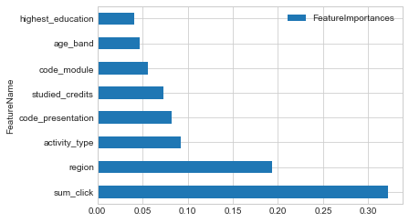

```python
SignificantFeatures.plot(x="FeatureName", y=["FeatureImportances"], kind="barh")
```

### KNN Classification

```python
from sklearn import neighbors
from sklearn.neighbors import KNeighborsClassifier

FeatureSelectedList = list(SignificantFeatures['FeatureName'])
X = data_encoder[FeatureSelectedList]

from sklearn.model_selection import train_test_split
X_train, X_test, y_train, y_test = train_test_split(X, labels, test_size = 0.25, random_state = 42)
np.random.seed(42)
```

```python
clf = neighbors.KNeighborsClassifier(n_neighbors = 50, p = 2)
clf.fit(X_train, y_train)
y_pred = clf.predict(X_test)
```

```python
from sklearn.metrics import accuracy_score
print ("Accuracy : %.2f %%" %(100*accuracy_score(y_test, y_pred)))
```

```
Accuracy : 51.12 %
```